# Analysis of count/mass systematicity: morphemes and length

```r
# Save:

save(nsyll_mdl,
     file = '../models/nsyllable_mdl.RData')
```

Show the model:

```r
nsyll_mdl
```

```
##  Family: negbinomial
##   Links: mu = log; shape = identity
## Formula: NSyll_0 ~ 1 + cnt_mass + major_etym + logfreq
##    Data: mono (Number of observations: 2516)
##   Draws: 4 chains, each with iter = 4000; warmup = 2000; thin = 1;
##          total post-warmup draws = 8000
##
## Population-Level Effects:
##                    Estimate Est.Error l-95% CI u-95% CI Rhat Bulk_ESS Tail_ESS
## Intercept              0.74      0.08     0.58     0.90 1.00     8772     6304
## cnt_massmass           0.23      0.07     0.10     0.36 1.00    11756     5671
## major_etymGermanic    -0.26      0.06    -0.38    -0.14 1.00     7939     6664
## major_etymLatin        0.26      0.08     0.09     0.43 1.00     9292     6991
## major_etymother       -0.36      0.08    -0.53    -0.19 1.00     8593     6943
## logfreq               -0.45      0.03    -0.51    -0.39 1.00    10340     6127
##
## Family Specific Parameters:
##       Estimate Est.Error l-95% CI u-95% CI Rhat Bulk_ESS Tail_ESS
## shape   170.71     98.05    50.68   424.25 1.00    11937     6131
##
## Draws were sampled using sampling(NUTS). For each parameter, Bulk_ESS
## and Tail_ESS are effective sample size measures, and Rhat is the potential
## scale reduction factor on split chains (at convergence, Rhat = 1).
```

```r
bayes_R2(nsyll_mdl)
```

```
##     Estimate  Est.Error      Q2.5     Q97.5
## R2 0.1819807 0.01893368 0.1455392 0.2199319
```

Perform a hypothesis test for the influence of count/mass:

```r
hypothesis(nsyll_mdl, 'cnt_massmass > 0')
```

```
## Hypothesis Tests for class b:
##           Hypothesis Estimate Est.Error CI.Lower CI.Upper Evid.Ratio Post.Prob
## 1 (cnt_massmass) > 0     0.23      0.07     0.12     0.34    2665.67         1
##   Star
## 1    *
## ---
## 'CI': 90%-CI for one-sided and 95%-CI for two-sided hypotheses.
## '*': For one-sided hypotheses, the posterior probability exceeds 95%;
## for two-sided hypotheses, the value tested against lies outside the 95%-CI.
## Posterior probabilities of point hypotheses assume equal prior probabilities.
```

For a Bayes R2 of only the `cnt_mass` effect, we want to construct a model that has everything but that, so that we can factor out its unique contribution with respect to the control variables `major_etym` and `logfreq`:

```r
nsyll_null_mdl <- brm(NSyll_0 ~ 1 +
                        major_etym + logfreq,
                      data = mono,

                      # Likelihood function:
                      family = negbinomial,

                      # Priors:
                      prior = priors,

                      # MCMC settings:
                      init = 0, seed = 666,
                      cores = 4, chains = 4,
                      warmup = 2000, iter = 4000)
```

```
## Trying to compile a simple C file
```

[output not shown]

```r
# Save:

save(nsyll_null_mdl,
     file = '../models/nsyllable_null_mdl.RData')
```

Check Bayes R2 and get unique effect by comparing the difference between the two models that only differ in `cnt_mass`:

```r
bayes_R2(nsyll_null_mdl)
```

```
##     Estimate  Est.Error      Q2.5     Q97.5
## R2 0.1739305 0.01849343 0.1382447 0.2111409
```

```r
# Difference between R2 to get unique contribution of count vs. mass:

bayes_R2(nsyll_mdl)[, 1] - bayes_R2(nsyll_null_mdl)[, 1]
```

```
## [1] 0.008050256
```

Plot the posterior distribution of the main model:

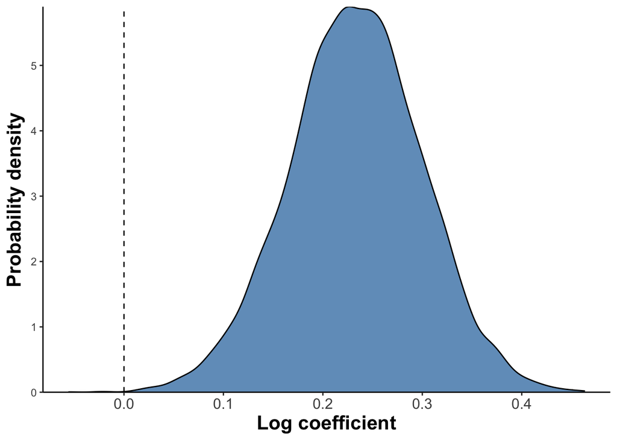

```r
# Plot basics:

nsyll_post_p <- posterior_samples(nsyll_mdl) %>%
  ggplot(aes(x = b_cnt_massmass)) +
  geom_vline(xintercept = 0, linetype = 'dashed') +
  geom_density(fill = 'steelblue',
               alpha = 0.8)
# Scales and axes:

nsyll_post_p <- nsyll_post_p +
  scale_y_continuous(expand = c(0, 0)) +
  ylab('Probability density') +
  xlab('Log coefficient')

# Cosmetics:

nsyll_post_p <- nsyll_post_p +
  theme_classic() +
  theme(axis.text.x = element_text(size = 12),
        axis.title.y = element_text(face = 'bold',
                                    size = 16,
                                    margin = margin(r = 5)),
        axis.title.x = element_text(face = 'bold',
                                    size = 16))

# Show and save:

nsyll_post_p
```

```r
ggsave('../figures/nsyll_posterior.pdf', nsyll_post_p,
       width = 5, height = 3)
```

Put both together into a double plot:

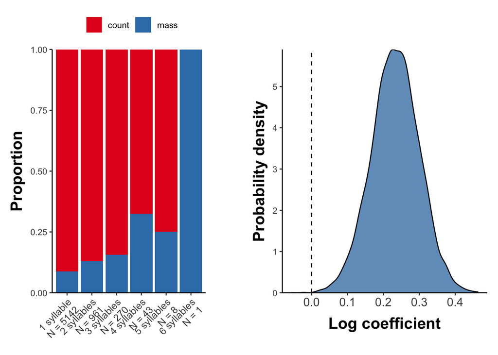

```r
# Fix title re-adjusting in double plot:

nsyll_post_p <- nsyll_post_p +
  theme(axis.title.x = element_text(margin = margin(t = -40)))

# Use patchwork to make a double plot:

nsyll_double_p <- nsyll_p + plot_spacer() + nsyll_post_p +
  plot_layout(widths = c(3, 0.5, 4))

# Show and save:

nsyll_double_p
```

```r
ggsave('../figures/nsyll_double_plot.pdf',
       width = 9, height = 4)
```

Make a plot of the conditional effects for this:

```r
# Extract conditional effects:

nsyll_cond <- conditional_effects(nsyll_mdl,
                                  effects = 'cnt_mass')

# Extract data frame with conditional effects and 95% credible intervals:

nsyll_pred_df <- nsyll_cond$cnt_mass
```

Make a ggplot out of this:

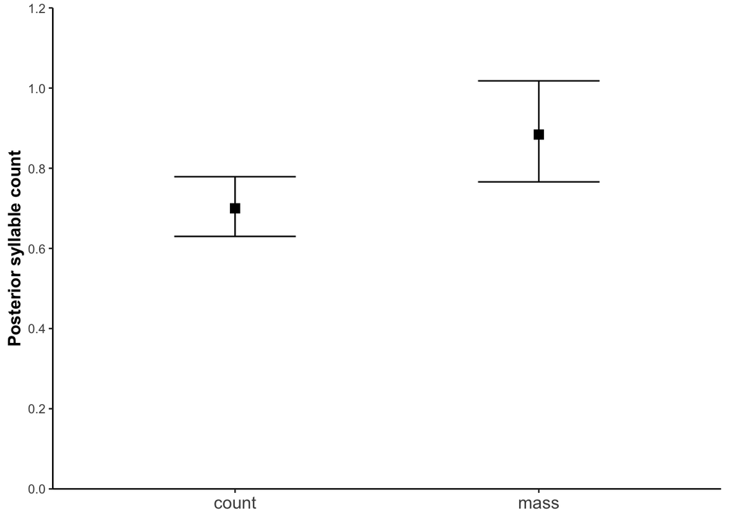

```r
# Plot basics:

nsyll_cond_p <- nsyll_pred_df %>%
  ggplot(aes(x = cnt_mass, y = estimate__)) +
  geom_point(size = 3, pch = 15) +
  geom_errorbar(aes(ymin = lower__, ymax = upper__),
                width = 0.4)

# Axes and labels:

nsyll_cond_p <- nsyll_cond_p +
  scale_y_continuous(limits = c(0, 1.2), breaks = seq(0, 1.2, 0.2),
                     expand = c(0, 0)) +
  ylab('Posterior syllable count') +
  xlab(NULL)

# Cosmetics:

nsyll_cond_p <- nsyll_cond_p +
  theme_classic() +
  theme(axis.text.x = element_text(size = 12),
        axis.title.y = element_text(face = 'bold',
                                    size = 12))

# Show and save:

nsyll_cond_p
```

```r
ggsave('../figures/nsyll_conditional_effects.pdf',
       width = 2, height = 3.5)
```

## Length analyses: phonemes

Does word length depend on etymology? For monosyllabic only:

```r
mono %>%
  filter(NSyll == 1) %>%
  group_by(major_etym) %>%
  summarize(NPhon_M = mean(NPhon, na.rm = TRUE),
            NPhon_SD = sd(NPhon, na.rm = TRUE)) %>%
  arrange(NPhon_M)
```

```
## # A tibble: 4 × 3
##   major_etym NPhon_M NPhon_SD
##   <chr>        <dbl>    <dbl>
## 1 other         3.41    0.711
## 2 Latin         3.42    0.647
## 3 French        3.51    0.749
## 4 Germanic      3.52    0.763
```

```r
nphon_etym_mdl <- brm(NPhon_0 ~ 1 + major_etym + logfreq + NSyll,
                      data = mono,

                      # Likelihood function:
                      family = negbinomial,

                      # Priors:
                      prior = priors,

                      # MCMC settings:
                      init = 0, seed = 666,
                      cores = 4, chains = 4,
                      warmup = 2000, iter = 4000)
```

```
## Trying to compile a simple C file
```

[output not shown]

```r
# Save:

save(nphon_etym_mdl,
     file = '../models/nphon_by_etymology_mdl.RData')
```

Show the model:

```r
nphon_etym_mdl
```

```
##  Family: negbinomial
##   Links: mu = log; shape = identity
## Formula: NPhon_0 ~ 1 + major_etym + logfreq + NSyll
##    Data: mono (Number of observations: 2516)
##   Draws: 4 chains, each with iter = 4000; warmup = 2000; thin = 1;
##          total post-warmup draws = 8000
##
## Population-Level Effects:
##                    Estimate Est.Error l-95% CI u-95% CI Rhat Bulk_ESS Tail_ESS
## Intercept              0.80      0.05     0.69     0.90 1.00     8828     5860
## major_etymGermanic    -0.02      0.03    -0.08     0.03 1.00     8307     5890
## major_etymLatin       -0.02      0.04    -0.10     0.06 1.00     8633     6539
## major_etymother       -0.07      0.04    -0.14     0.00 1.00     7910     6105
## logfreq               -0.06      0.01    -0.09    -0.04 1.00    10812     6092
## NSyll                  0.36      0.01     0.34     0.39 1.00    10117     6987
##
## Family Specific Parameters:
##       Estimate Est.Error l-95% CI u-95% CI Rhat Bulk_ESS Tail_ESS
## shape   604.94    176.12   332.43  1016.84 1.00    10773     5890
##
## Draws were sampled using sampling(NUTS). For each parameter, Bulk_ESS
## and Tail_ESS are effective sample size measures, and Rhat is the potential
## scale reduction factor on split chains (at convergence, Rhat = 1).
```

```r
bayes_R2(nphon_etym_mdl)
```

```
##     Estimate  Est.Error      Q2.5     Q97.5
## R2 0.6655346 0.01362045 0.6363461 0.6892636
```

Get the comparison null model for LOO comparisons:

```r
nphon_etym_mdl_null <- brm(NPhon_0 ~ 1 + NSyll + logfreq,
                           data = mono,

                           # Likelihood function:
                           family = negbinomial,

                           # Priors:
                           prior = priors,

                           # MCMC settings:
                           init = 0, seed = 666,
                           cores = 4, chains = 4,
                           warmup = 2000, iter = 4000)
```

```
## Trying to compile a simple C file
```

[output not shown]

```r
# Save:

save(nphon_etym_mdl_null,
     file = '../models/nphoneme_by_etymology_mdl_null.RData')
```

Do LOO-CV for both:

```r
nphon_etym_loo <- loo(nphon_etym_mdl)
nphon_etym_null_loo <- loo(nphon_etym_mdl_null)

# LOO compare:

nphon_etym_loo_compare <- loo_compare(nphon_etym_loo,
                                      nphon_etym_null_loo)

# Show:

nphon_etym_loo_compare
```

```
##                     elpd_diff se_diff
## nphon_etym_mdl       0.0       0.0
## nphon_etym_mdl_null -0.1       0.9
```